# WFP datasets wrangling - Chad : Assistency

Aboubacar HEMA

2025-03-04

```r
library(haven)
library(labelled) # for general functions to work with labelled data
library(tidyverse) # general wrangling
library(dplyr)
library(Hmisc)
library(gtsummary) # to demonstrate automatic use of variable labels in summary tables
library(readxl)
library(foreign)
library(sjPlot)
library(sjmisc)
library(sjlabelled) # for example efc data set with variable labels
library(stringr)
```

```r
rm(list = ls())
```

```r
dir_input_data = "C:/Users/AHema/OneDrive - CGIAR/Desktop/WFP Resilience dataset/data/input_data/Chad"
dir_output_data = "C:/Users/AHema/OneDrive - CGIAR/Desktop/WFP Resilience dataset/data/output_data/Chad"
```

```r
Chad_Harmonization_variables <- read_excel(paste0(dir_input_data,"/Chad_Harmonization.xlsx"),
    sheet = "variables_harmonization")
#View(Chad_Harmonization_variables)

Chad_Harmonization_description <- read_excel(paste0(dir_input_data,"/Chad_Harmonization.xlsx"),
    sheet = "description")
#View(Chad_Harmonization_description)
```

```r
lst_data = Chad_Harmonization_description$Data
lst_test = Chad_Harmonization_description$Name

for(i in 1:length(lst_data)) {                              # Head of for-loop
  assign(lst_test[i],                                   # Read and store data frames
         read_sav(paste0(dir_input_data,"/",lst_data[i])))
}
```

```r
for (j in 1:length(lst_test)){
         df=  get(lst_test[j], envir = .GlobalEnv)
          for (i in 1:nrow(Chad_Harmonization_variables)){
            df[,Chad_Harmonization_variables$NewVariable_Name[i]]=ifelse(is.na(Chad_Harmonization_variables[i,lst_test[j]]),NA,df[,Chad_Harmonization_variables[i,lst_test[j]][[1]]])
          }

    df<-df %>% select(Chad_Harmonization_variables$NewVariable_Name)
    assign(lst_test[j],                                   # Read and store data frames
         df)
#write_sav(df, paste0(dir_output_data,"/",lst_test[j],".sav"))
#write_dta(df, paste0(dir_output_data,"/",lst_test[j],".dta"))


}
```

```r
Chad_pdm_2022$ID = 1:nrow(Chad_pdm_2022)
```

## 0.1 Food consumption score

The Food consumption Score (FCS) is an index that aggregates household-level data on the diversity and frequency of food groups consumed over the last 7 days. It is then weighted according to the relative nutritional value of the consumed food groups. Food groups containing nutritionally dense foods (e.g. animal based products) are given greater weight than those containing less nutritional value (e.g. tubers) as follows: (main staples:2, pulses:3, vegetables:1, fruit:1, meat or fish:4, milk:4, sugar:0.5, oil:0.5).

```r
key_vars = c("ID"
             # "YEAR",
             #  "SURVEY",
             #  "ADMIN0Name",
             #  "adm0_ocha",
             #  "adm1_ocha",
             #  "adm2_ocha",
             # "Key_with_subset_data",
             # "SvyDatePDM",
             # #"RESPConsent",
             # "ADMIN1Name",
             # "ADMIN2Name",
             # # "ADMIN3Name",
             # # "sous_bureau",
             # # "site",
             # # "site_autre",
             # "village",
             # #"village_autre",
             # "Longitude",
             # "Latitude",
             # "Longitude_precision",
             # "Latitude_precision"
             )
```

```r
var_needed = c("SCA",
               "FCS",
               "rCSI"
,"FCSStap",
"FCSStapSRf",
"FCSPulse",
"FCSPulseSRf",
"FCSDairy",
"FCSDairySRf",
"FCSPr",
"FCSPrSRf",
"FCSPrMeatF",
"FCSPrMeatO",
"FCSPrFish",
"FCSPrEgg",
"FCSVeg",
"FCSVegSRf",
"FCSVegOrg",
"FCSVegGre",
"FCSFruit",
"FCSFruitSRf",
"FCSFruitOrg",
"FCSFat",
"FCSFatSRf",
"FCSSugar",
"FCSSugarSRf",
"FCSCond",
"FCSCondSRf",
"rCSILessQlty",
"rCSIBorrow",
"rCSIMealSize",
"rCSIMealAdult",
"rCSIMealNb",
"LhCSIStress1",
"LhCSIStress2",
"LhCSIStress3",
"LhCSIStress4",
"LhCSICrisis1",
"LhCSICrisis2",
"LhCSICrisis3",
"LhCSIEmergency1",
"LhCSIEmergency2",
"LhCSIEmergency3")
```

### 0.1.1 FCS : Céréales et tubercules

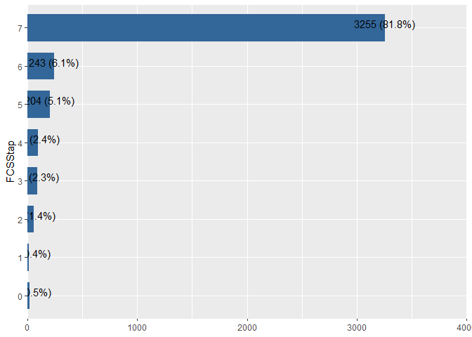

```r
#expss::val_lab(Chad_baseline_2018$FCSStap)
Chad_baseline_2018 %>%
  sjPlot::plot_frq(coord.flip =T,FCSStap,show.na = T)
```

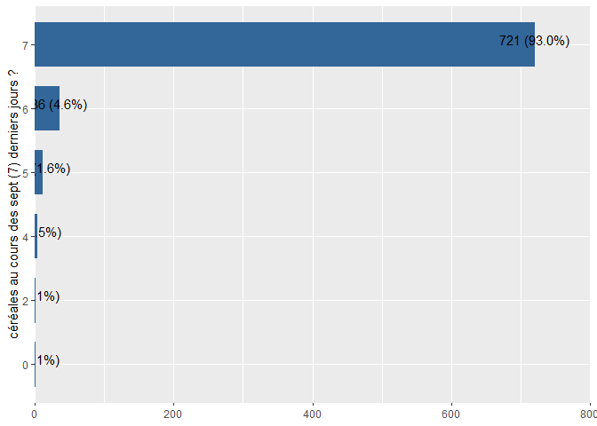

```r
Chad_ea_2019%>%
  sjPlot::plot_frq(coord.flip =T,FCSStap,show.na = T)
```

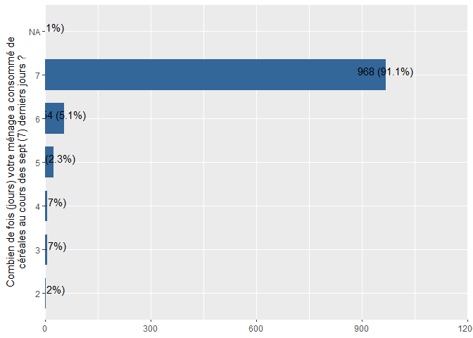

```r
Chad_ea_2020%>%
  sjPlot::plot_frq(coord.flip =T,FCSStap,show.na = T)
```

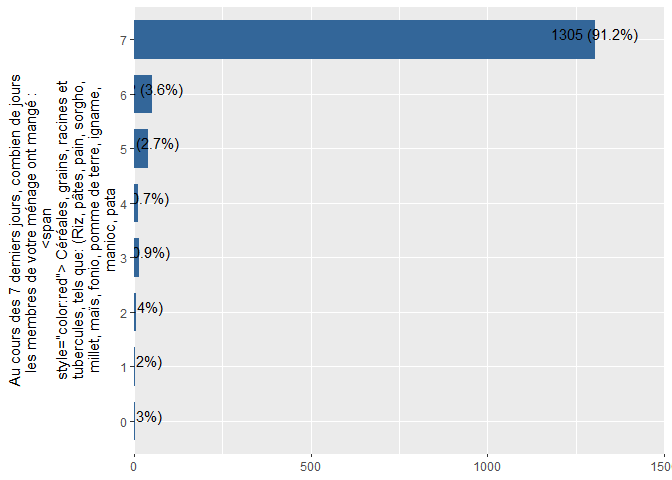

```r
Chad_ea_2021%>%
  sjPlot::plot_frq(coord.flip =T,FCSStap,show.na = T)
```

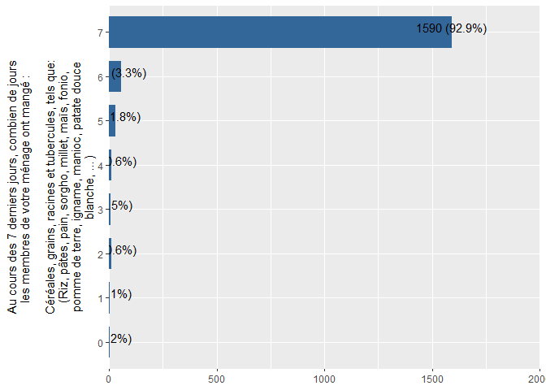

```r
Chad_ea_2022%>%
  sjPlot::plot_frq(coord.flip =T,FCSStap,show.na = T)
```

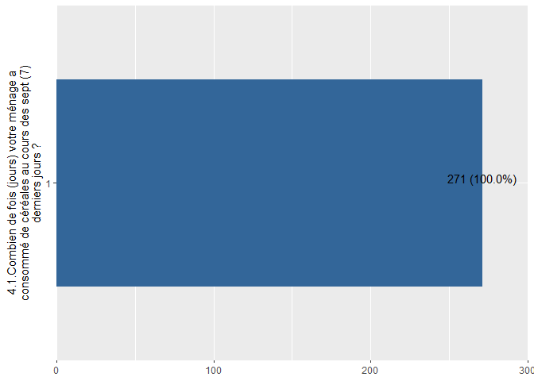

```r
Chad_pdm_2020%>%
  sjPlot::plot_frq(coord.flip =T,FCSStap,show.na = T)
```

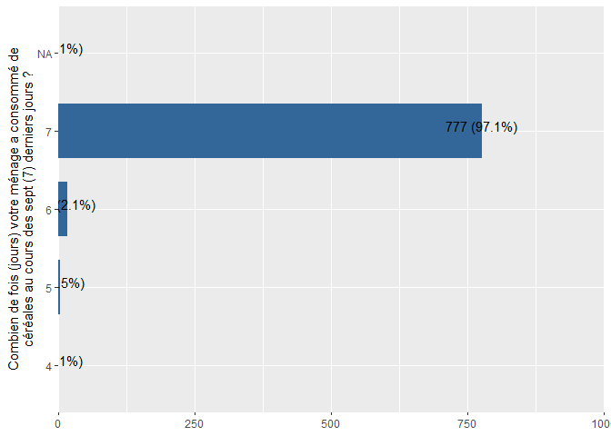

```r
Chad_pdm_2021%>%
  sjPlot::plot_frq(coord.flip =T,FCSStap,show.na = T)
```

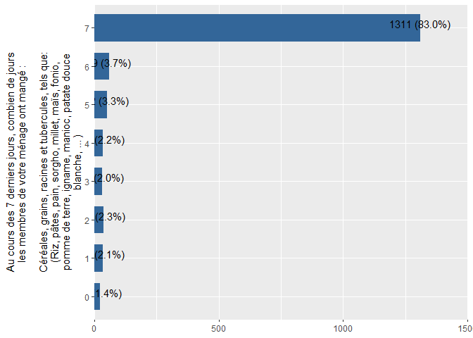

```r
Chad_pdm_2022%>%
  sjPlot::plot_frq(coord.flip =T,FCSStap,show.na = T)
```

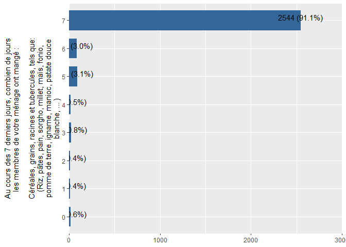

```r
Chad_ea_2023%>%
  sjPlot::plot_frq(coord.flip =T,FCSStap,show.na = T)
```

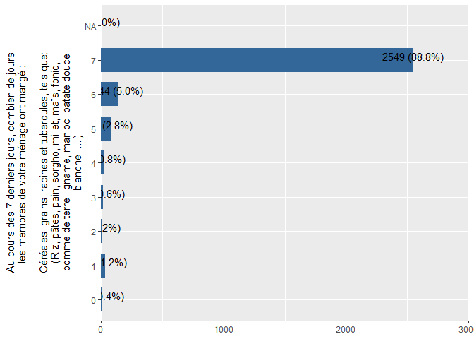

```r
Chad_pdm_2023%>%
  sjPlot::plot_frq(coord.flip =T,FCSStap,show.na = T)
```

### 0.1.2 FCS : Céréales et tubercules - Sources

```r
# Codes d’acquisition des aliments
# 1 = Production propre (récoltes, élevage) ; 2 = Pêche / Chasse ; 3 = Cueillette ; 4 = Prêts ; 5 = Marché (achat avec des espèces) ; 6 = Marché (achat à crédit) ;
# 7 = Mendicité ; 8 = Troc travail ou biens contre des aliments ; 9 = Dons (aliments) de membres de la famille ou d’amis ; 10 = Aide alimentaire de la société civile, ONG, gouvernement, PAM, etc.
```

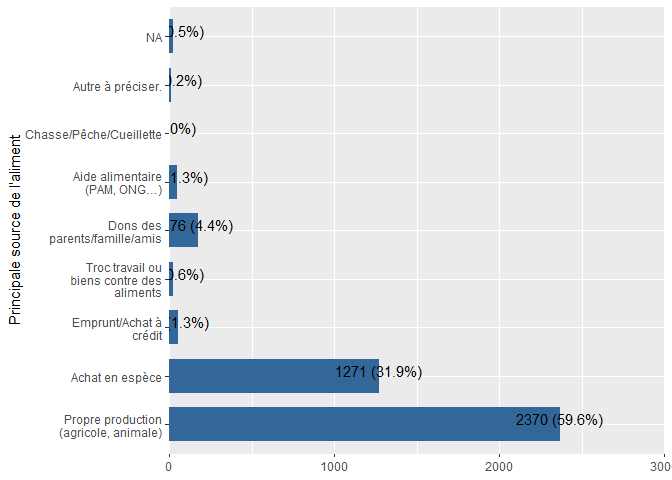

```r
expss::val_lab(Chad_baseline_2018$FCSStapSRf)
Chad_baseline_2018 %>%
  sjPlot::plot_frq(coord.flip =T,FCSStapSRf,show.na = T)
```

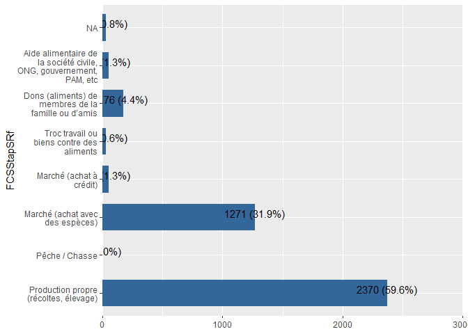

```r
Chad_baseline_2018 <-
  Chad_baseline_2018 %>% dplyr::mutate_at(c("FCSStapSRf"),recode,"1"=1,"2"=5,"3"=6,"4"=8,"5"=9,"6"=10,"7"=2,"8"=NA_real_)
Chad_baseline_2018$FCSStapSRf <- labelled::labelled(Chad_baseline_2018$FCSStapSRf, c(`Production propre (récoltes, élevage)` = 1, `Pêche / Chasse` = 2, Cueillette= 3,`Prêts`=4,`Marché (achat avec des espèces)`=5,`Marché (achat à crédit)`=6,`Mendicité`=7,`Troc travail ou biens contre des aliments`=8,`Dons (aliments) de membres de la famille ou d’amis`=9,`Aide alimentaire de la société civile, ONG, gouvernement, PAM, etc`=10))
#check labels
expss::val_lab(Chad_baseline_2018$FCSStapSRf)
Chad_baseline_2018 %>%
  plot_frq(coord.flip =T,FCSStapSRf,show.na = T)
```

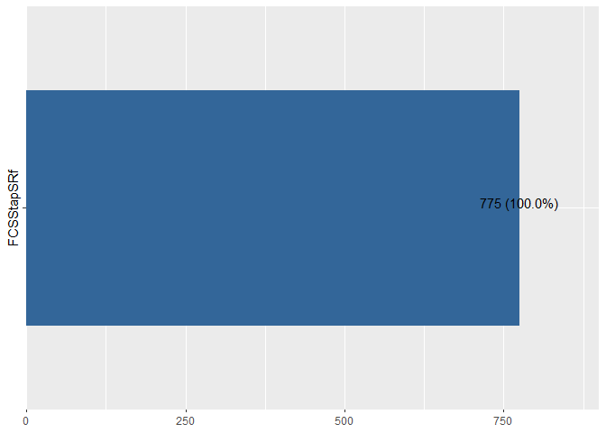

```r
Chad_ea_2019%>%
  sjPlot::plot_frq(coord.flip =T,FCSStapSRf,show.na = T)
```

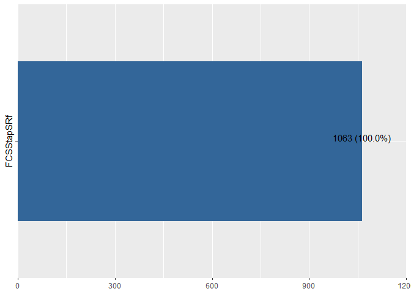

```r
Chad_ea_2020%>%
  sjPlot::plot_frq(coord.flip =T,FCSStapSRf,show.na = T)
```

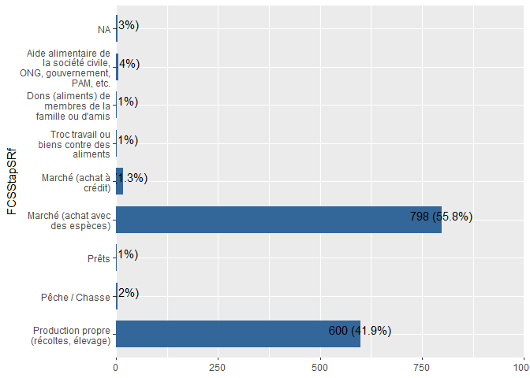

```r
expss::val_lab(Chad_ea_2021$FCSStapSRf)

Chad_ea_2021%>%
  sjPlot::plot_frq(coord.flip =T,FCSStapSRf,show.na = T)
```

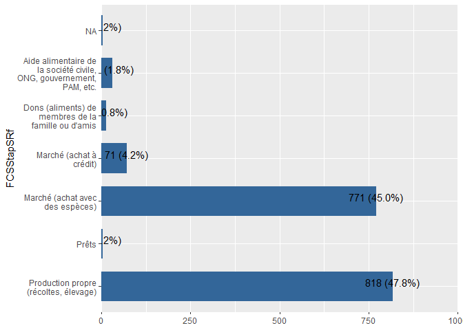

```r
expss::val_lab(Chad_ea_2022$FCSStapSRf)
Chad_ea_2022%>%
  sjPlot::plot_frq(coord.flip =T,FCSStapSRf,show.na = T)
```

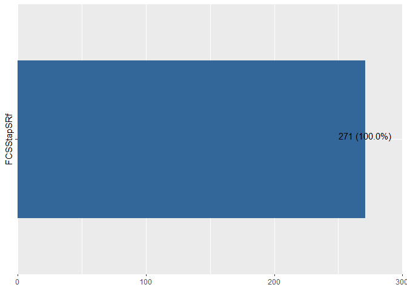

```r
Chad_pdm_2020%>%
  sjPlot::plot_frq(coord.flip =T,FCSStapSRf,show.na = T)
```

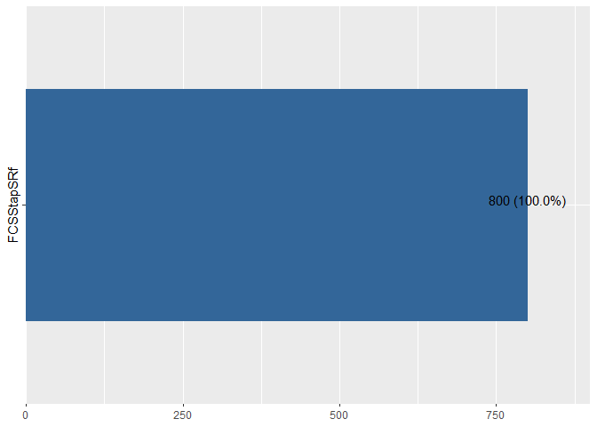

```r
Chad_pdm_2021%>%
  sjPlot::plot_frq(coord.flip =T,FCSStapSRf,show.na = T)
```

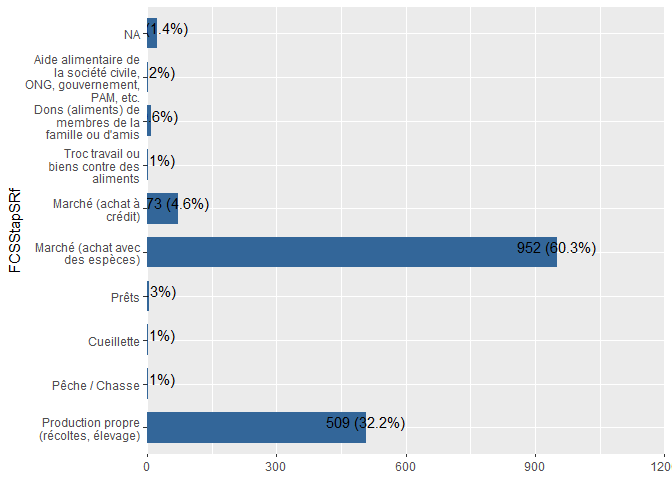

```r
expss::val_lab(Chad_pdm_2022$FCSStapSRf)
Chad_pdm_2022%>%
  sjPlot::plot_frq(coord.flip =T,FCSStapSRf,show.na = T)
```

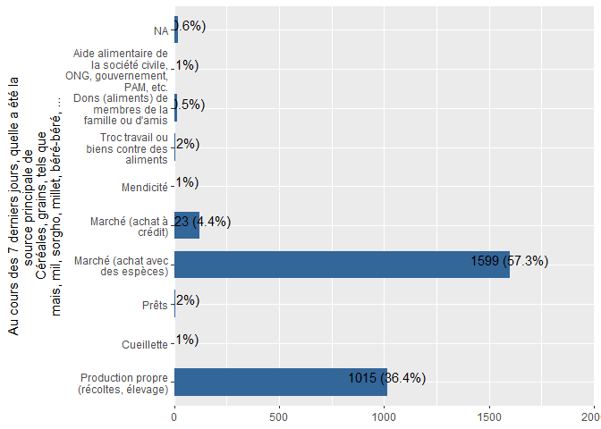

```r
expss::val_lab(Chad_ea_2023$FCSStapSRf)
Chad_ea_2023%>%
  sjPlot::plot_frq(coord.flip =T,FCSStapSRf,show.na = T)
```

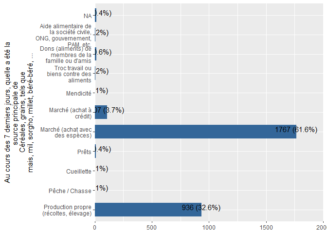

```r
expss::val_lab(Chad_pdm_2023$FCSStapSRf)
Chad_pdm_2023%>%
  sjPlot::plot_frq(coord.flip =T,FCSStapSRf,show.na = T)
```

### 0.1.3 FCS : Légumineuses

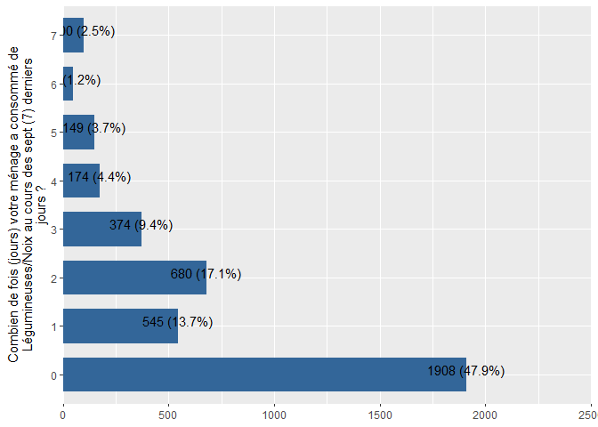

```r
Chad_baseline_2018 %>%
  sjPlot::plot_frq(coord.flip =T,FCSPulse,show.na = T)
```

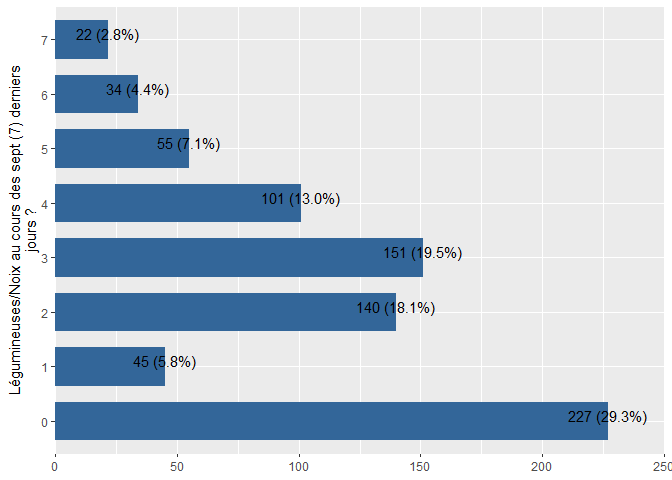

```r
Chad_ea_2019%>%
  sjPlot::plot_frq(coord.flip =T,FCSPulse,show.na = T)
```

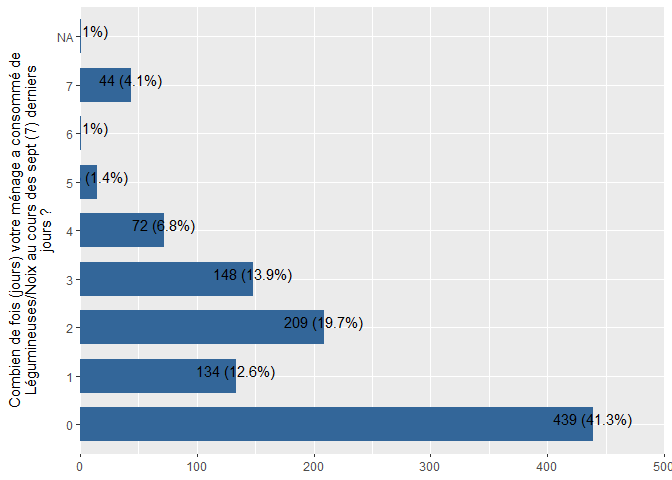

```r
Chad_ea_2020%>%
  sjPlot::plot_frq(coord.flip =T,FCSPulse,show.na = T)
```

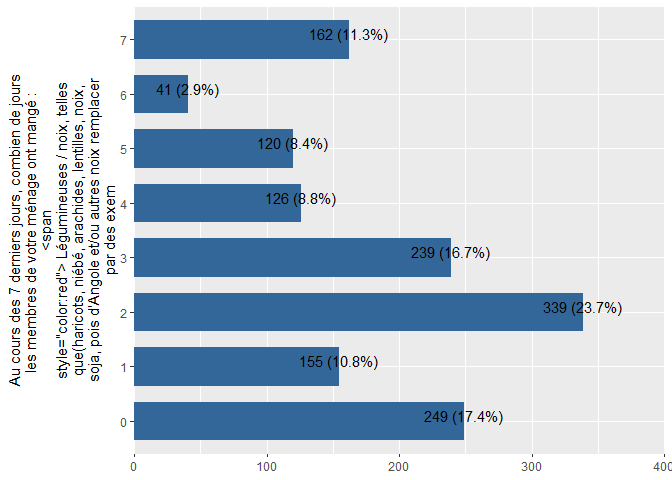

```r
Chad_ea_2021%>%
  sjPlot::plot_frq(coord.flip =T,FCSPulse,show.na = T)
```

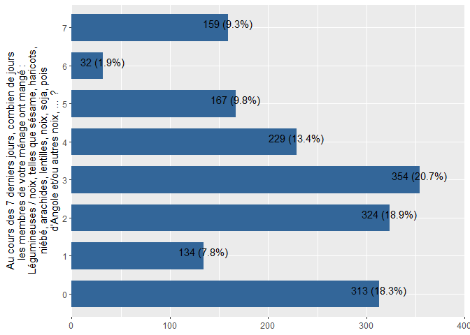

```r
Chad_ea_2022%>%
  sjPlot::plot_frq(coord.flip =T,FCSPulse,show.na = T)
```

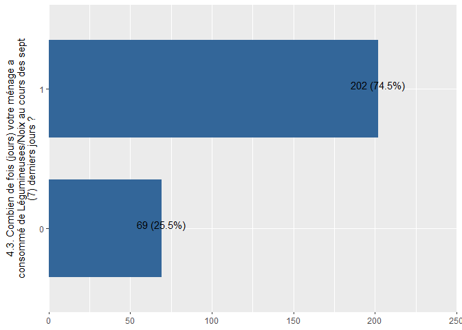

```r
Chad_pdm_2020%>%
  sjPlot::plot_frq(coord.flip =T,FCSPulse,show.na = T)
```

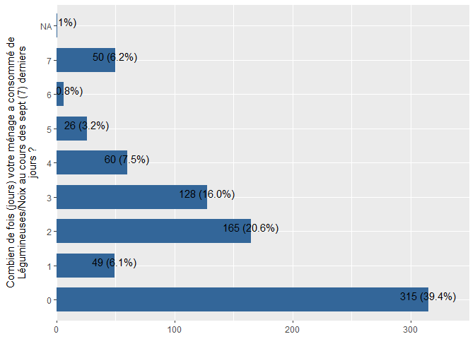

```r
Chad_pdm_2021%>%
  sjPlot::plot_frq(coord.flip =T,FCSPulse,show.na = T)
```

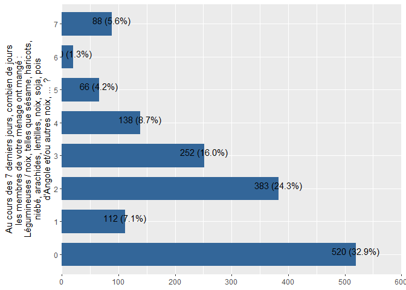

```r
Chad_pdm_2022%>%
  sjPlot::plot_frq(coord.flip =T,FCSPulse,show.na = T)
```

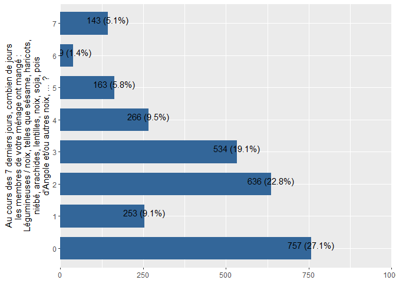

```r
Chad_ea_2023%>%
  sjPlot::plot_frq(coord.flip =T,FCSPulse,show.na = T)
```

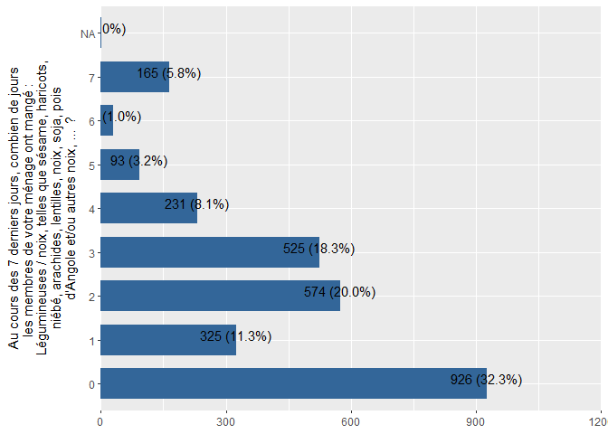

```r
Chad_pdm_2023%>%
  sjPlot::plot_frq(coord.flip =T,FCSPulse,show.na = T)
```